# Notebook 07: Perform Deconvolution

Author

Shirshak Aryal

Published

June 30, 2026

Perform **Deconvolution** on the **filtered `unstranded` raw counts matrix**. The primary purpose of Deconvolution in this project is to **estimate the relative abundance of distinct cell types present in each tumor sample**, using **pre-curated GBM-specific marker gene signatures** derived from the **Neftel et al. 2019 single-cell GBM atlas** and the **Moreno et al. 2022 immune cell reference.**

Deconvolution provides a **cellular-level view of each tumor sample**, complementing the **gene-level** findings from **DE analysis** and **pathway enrichment** by revealing **which cell types are driving the observed transcriptomic differences** between Proneural and Mesenchymal GBM.

The steps are as follows:

- **Setup**: Download the **`GBMdeconvoluteR` marker gene reference files** from GitHub.
- **Deconvolution**: Run **`MCPcounter`** using the marker gene reference files to estimate **cell type abundance scores per sample**, using:
  - **Primary reference**:
    - **Neoplastic (i.e. tumor) marker genes**: **Neftel** et al. (2019)
    - **Immune marker genes: Moreno** et al. (2022)
  - **Confirmatory reference**:
    - **Neoplastic (i.e. tumor) marker genes: Moreno** et al. (2022)
    - **Immune marker genes: Moreno** et al. (2022)

  to validate the results.
- **Visualisation**: Plot **median cell type abundance scores** grouped by subtype (Proneural vs Mesenchymal) to assess **differences in cellular composition between the two subtypes**.

**A note on GBM subtype biology**:

- **PN and ME subtype labels** used throughout **this project** derive from **Verhaak et al. (2010)**
  - **Verhaak used bulk RNA-seq to classify GBM tumors** into **four transcriptional subtypes** (Proneural, Mesenchymal, Classical, Neural).
  - These subtypes were **the field’s primary framework for GBM heterogeneity** for nearly a **decade**.
- However, **Neftel et al. (2019)** subsequently applied **single-cell RNA-seq to GBM**
  - Neftel **revealed** that **individual tumors are not transcriptionally homogeneous**
    - **Each tumor** contains a **mixture of malignant cell states**:
      - **MES-like:** **MES**enchymal like
      - **NPC-like:** **N**eural **P**rogenitor **C**ell-like
      - **OPC-like:** **O**ligodendrocyte **P**rogenitor **C**ell-like
      - **AC-like:** **A**stro**C**yte-like

      that **co-exist** and **can change identities** **in response to microenvironmental signals or treatment pressure**.
  - Under this updated understanding, a **“Mesenchymal tumor”** in the **Verhaak** framework is better interpreted as a **tumor in which MES-like malignant cells dominate the bulk RNA-seq signal**. not a fundamentally distinct cancer type.

**This project operates within the Verhaak bulk subtype framework** (using TCGA GBM data), but **interprets findings through the lens of Neftel’s single-cell insights** **in Notebook 07 (this notebook)**, which estimates the **proportions of Neftel-defined cell states** from bulk expression data.

## 1. Import Libraries

```r
library(tidyverse)        # data manipulation and visualisation
library(patchwork)        # combine multiple ggplot2 plots into one canvas
library(MCPcounter)       # cell type abundance estimation from bulk RNA-seq using marker gene expression
library(clusterProfiler)  # gene ID conversion (bitr)
library(pheatmap)         # colorful heatmaps
library(org.Hs.eg.db)     # human gene annotation database


cat("\nLibraries loaded successfully\n")
```

```
Libraries loaded successfully
```

```r
cat("tidyverse version:         ", as.character(packageVersion("tidyverse")), "\n")
```

```
tidyverse version:          2.0.0
```

```r
cat("patchwork version:         ", as.character(packageVersion("patchwork")), "\n")
```

```
patchwork version:          1.3.2
```

```r
cat("MCPcounter version:        ", as.character(packageVersion("MCPcounter")), "\n")
```

```
MCPcounter version:         1.2.0
```

```r
cat("clusterProfiler version:   ", as.character(packageVersion("clusterProfiler")), "\n")
```

```
clusterProfiler version:    4.18.4
```

```r
cat("pheatmap version:          ", as.character(packageVersion("pheatmap")), "\n")
```

```
pheatmap version:           1.0.13
```

```r
cat("org.Hs.eg.db version:      ", as.character(packageVersion("org.Hs.eg.db")), "\n")
```

```
org.Hs.eg.db version:       3.22.0
```

## 2. Load Data

### 2.1. Load Filtered Counts Matrix

```r
filtered_counts_matrix <- readRDS("../01_data/02_processed/04_filtered_counts_matrix.rds")
cat("Filtered counts matrix loaded:", nrow(filtered_counts_matrix), "genes x", ncol(filtered_counts_matrix), "samples\n")
```

```
Filtered counts matrix loaded: 16164 genes x 180 samples
```

### 2.2. Load Filtered Tumor Subtype Information

```r
tumor_subtype_info <- readRDS("../01_data/02_processed/05_filtered_tumor_subtype_info.rds")
cat("Filtered tumor subtype info loaded:", nrow(tumor_subtype_info), "samples\n")
```

```
Filtered tumor subtype info loaded: 180 samples
```

## 3. Perform Deconvolution

### 3.1. Download `GBMdeconvoluteR` Marker Gene Reference Datasets

This project will perform **two modes of deconvolution**:

- **Primary**:
  - **Neoplastic (i.e. tumor) marker genes**: **Neftel** et al. 2019
  - **Immune marker genes: Moreno** et al. 2022
- **Confirmatory**:
  - **Neoplastic (i.e. tumor) marker genes: Moreno** et al. 2022
  - **Immune marker genes: Moreno** et al. 2022

#### 3.1.1. Download Primary Deconvolution Reference Datasets

```r
# base URL
base_url <- "https://raw.githubusercontent.com/GliomaGenomics/GBMDeconvoluteR/main/data/"


# Neftel neoplastic
download.file(
  url      = paste0(base_url, "Neftel_et_al_2019_four_state_neoplastic_markers.rds"),
  destfile = "../01_data/01_raw/03_deconvolution_references/01_neftel_neoplastic/neftel_neoplastic_markers.rds",
  mode     = "wb"
)

# Moreno immune
download.file(
  url      = paste0(base_url, "Moreno_et_al_2022_lvl3_immune_markers.rds"),
  destfile = "../01_data/01_raw/03_deconvolution_references/01_neftel_neoplastic/moreno_immune_markers.rds",
  mode     = "wb"
)



cat("Primary deconvolution reference datasets downloaded:\n")
```

```
Primary deconvolution reference datasets downloaded:
```

```r
cat("  neftel_neoplastic_markers.rds\n")
```

```
  neftel_neoplastic_markers.rds
```

```r
cat("  moreno_immune_markers.rds\n")
```

```
  moreno_immune_markers.rds
```

#### 3.1.2. Download Confirmatory Deconvolution Reference Datasets

```r
# base URL (same as in primary)
base_url <- "https://raw.githubusercontent.com/GliomaGenomics/GBMDeconvoluteR/main/data/"


# Moreno neoplastic
download.file(
  url      = paste0(base_url, "Moreno_et_al_2022_lvl3_neoplastic_markers.rds"),
  destfile = "../01_data/01_raw/03_deconvolution_references/02_moreno_neoplastic/moreno_neoplastic_markers.rds",
  mode     = "wb"
)

# Moreno immune (same as in primary, but saved separately with Moreno neoplastic)
download.file(
  url      = paste0(base_url, "Moreno_et_al_2022_lvl3_immune_markers.rds"),
  destfile = "../01_data/01_raw/03_deconvolution_references/02_moreno_neoplastic/moreno_immune_markers.rds",
  mode     = "wb"
)



cat("Confirmatory deconvolution reference files downloaded:\n")
```

```
Confirmatory deconvolution reference files downloaded:
```

```r
cat("  moreno_neoplastic_markers.rds\n")
```

```
  moreno_neoplastic_markers.rds
```

```r
cat("  moreno_immune_markers.rds\n")
```

```
  moreno_immune_markers.rds
```

### 3.2. Load And Inspect Marker Gene Reference Datasets

```r
# Primary: Neftel neoplastic + Moreno immune
neftel_neoplastic <- readRDS("../01_data/01_raw/03_deconvolution_references/01_neftel_neoplastic/neftel_neoplastic_markers.rds")
moreno_immune_primary   <- readRDS("../01_data/01_raw/03_deconvolution_references/01_neftel_neoplastic/moreno_immune_markers.rds")

# Confirmatory: Moreno neoplastic + Moreno immune
moreno_neoplastic <- readRDS("../01_data/01_raw/03_deconvolution_references/02_moreno_neoplastic/moreno_neoplastic_markers.rds")
moreno_immune_confirmatory   <- readRDS("../01_data/01_raw/03_deconvolution_references/02_moreno_neoplastic/moreno_immune_markers.rds")



cat("Neftel neoplastic markers:\n")
```

```
Neftel neoplastic markers:
```

```r
print(head(neftel_neoplastic))
```

```
$AC
 [1] "CST3"    "S100B"   "SLC1A3"  "HEPN1"   "HOPX"    "MT3"     "SPARCL1"
 [8] "MLC1"    "GFAP"    "FABP7"   "BCAN"    "PON2"    "METTL7B" "SPARC"
[15] "GATM"    "RAMP1"   "PMP2"    "AQP4"    "DBI"     "EDNRB"   "PTPRZ1"
[22] "CLU"     "PMP22"   "ATP1A2"  "S100A16" "HEY1"    "PCDHGC3" "TTYH1"
[29] "NDRG2"   "PRCP"    "ATP1B2"  "AGT"     "PLTP"    "GPM6B"   "F3"
[36] "RAB31"   "PPAP2B"  "ANXA5"   "TSPAN7"

$MES
 [1] "CHI3L1"   "ANXA2"    "ANXA1"    "CD44"     "VIM"      "MT2A"
 [7] "C1S"      "NAMPT"    "EFEMP1"   "C1R"      "SOD2"     "IFITM3"
[13] "TIMP1"    "SPP1"     "A2M"      "S100A11"  "MT1X"     "S100A10"
[19] "FN1"      "LGALS1"   "S100A16"  "CLIC1"    "MGST1"    "RCAN1"
[25] "TAGLN2"   "NPC2"     "SERPING1" "C8orf4"   "EMP1"     "APOE"
[31] "CTSB"     "C3"       "LGALS3"   "MT1E"     "EMP3"     "SERPINA3"
```

[output cut: 40 more lines]

```r
cat("\nMoreno immune markers:\n")
```

```
Moreno immune markers:
```

```r
print(head(moreno_immune_primary))
```

```
# A tibble: 6 × 2
  `HUGO symbols` `Cell population`
  <chr>          <chr>
1 SLC1A2         Astrocyte
2 SPARCL1        Astrocyte
3 CPE            Astrocyte
4 ALDOC          Astrocyte
5 CLU            Astrocyte
6 SLC1A3         Astrocyte
```

```r
cat("\nMoreno neoplastic markers:\n")
```

```
Moreno neoplastic markers:
```

```r
print(head(moreno_neoplastic))
```

```
$AC
 [1] "FABP7"    "EGFR"     "MT3"      "GFAP"     "PTN"      "CHCHD2"
 [7] "CLU"      "CST3"     "MIR9-1HG" "SEC61G"   "DBI"      "PTPRZ1"
[13] "CKB"      "HOPX"     "BCAN"     "CRYAB"    "NIPSNAP2" "ID3"
[19] "SPARCL1"  "PMP2"     "CNN3"     "GPM6B"    "NOVA1"    "CCT6A"
[25] "MTRNR2L8" "AQP4"     "IGFBP2"   "VIM"      "TTYH1"    "RAMP1"
[31] "TUBB2B"   "S100B"    "METRN"    "GAP43"    "CALD1"    "S100A16"
[37] "ID1"      "NMB"      "ID4"      "FXYD6"    "MT1X"     "PDGFRA"
[43] "AGT"      "PCSK1N"   "SUMF2"    "BAALC"    "GATM"     "NES"
[49] "TSC22D4"  "GPM6A"

$MES
 [1] "CHI3L1"  "IGFBP5"  "MT1X"    "MT2A"    "SEC61G"  "CLU"     "LGALS3"
 [8] "SPARCL1" "HILPDA"  "VEGFA"   "IGFBP2"  "AKAP12"  "MT3"     "MT1E"
[15] "IGFBP3"  "CPE"     "TIMP1"   "NRN1"    "VOPP1"   "GAPDH"   "SOD2"
```

[output cut: 31 more lines]

### 3.3. Prepare Marker Gene Reference Lists

```r
# convert neoplastic named lists to dataframe format
neoplastic_to_df <- function(marker_list) {
  data.frame(
    `HUGO symbols`    = unlist(marker_list),
    `Cell population` = rep(names(marker_list), lengths(marker_list)),
    row.names         = NULL,
    check.names       = FALSE
  )
}

neftel_neoplastic_df  <- neoplastic_to_df(neftel_neoplastic)
moreno_neoplastic_df  <- neoplastic_to_df(moreno_neoplastic)


# get cell types already in neoplastic markers
neoplastic_cell_types_primary      <- unique(neftel_neoplastic_df$`Cell population`)
neoplastic_cell_types_confirmatory <- unique(moreno_neoplastic_df$`Cell population`)

# remove duplicate cell types from immune markers before combining
moreno_immune_primary_dedup      <- moreno_immune_primary %>%
                                    filter(!(`Cell population` %in% neoplastic_cell_types_primary))
moreno_immune_confirmatory_dedup <- moreno_immune_confirmatory %>%
                                    filter(!(`Cell population` %in% neoplastic_cell_types_confirmatory))


# combine neoplastic and immune dataframes
primary_markers_df      <- bind_rows(neftel_neoplastic_df, moreno_immune_primary_dedup)
confirmatory_markers_df <- bind_rows(moreno_neoplastic_df, moreno_immune_confirmatory_dedup)

cat("Primary markers nrow:           ", nrow(primary_markers_df), "\n")
```

```
Primary markers nrow:            1007
```

```r
cat("Primary cell types:             ", paste(unique(primary_markers_df$`Cell population`), collapse = ", "), "\n")
```

```
Primary cell types:              AC, MES, NPC, OPC, Astrocyte, Oligodendrocyte, Neuron, Radial glial, Monocytes, TAM, Microglia, DC, Mast cells, T cells, NK cells, B cells, Plasma B, Mural cell, Endothelial
```

```r
cat("\nConfirmatory markers nrow:      ", nrow(confirmatory_markers_df), "\n")
```

```
Confirmatory markers nrow:       934
```

```r
cat("Confirmatory cell types:        ", paste(unique(confirmatory_markers_df$`Cell population`), collapse = ", "), "\n")
```

```
Confirmatory cell types:         AC, MES, NPC, OPC, Astrocyte, Oligodendrocyte, Neuron, Radial glial, Monocytes, TAM, Microglia, DC, Mast cells, T cells, NK cells, B cells, Plasma B, Mural cell, Endothelial
```

### 3.4. Run `MCPcounter`

```r
# expression matrix must have gene symbols as rownames
# convert Ensembl IDs to gene symbols first
ensembl_ids_clean <- gsub("\\..*", "", rownames(filtered_counts_matrix))

symbol_map <- bitr(
  ensembl_ids_clean,
  fromType = "ENSEMBL",
  toType   = "SYMBOL",
  OrgDb    = org.Hs.eg.db
)


# subset matrix to mapped genes and rename rows to gene symbols
mapped_idx        <- match(symbol_map$ENSEMBL, ensembl_ids_clean)
expression_symbol <- filtered_counts_matrix[mapped_idx, ]
rownames(expression_symbol) <- symbol_map$SYMBOL





# run MCPcounter
deconv_primary <- MCPcounter.estimate(
  expression   = expression_symbol,
  featuresType = "HUGO_symbols",
  genes        = primary_markers_df
)

deconv_confirmatory <- MCPcounter.estimate(
  expression   = expression_symbol,
  featuresType = "HUGO_symbols",
  genes        = confirmatory_markers_df
)




cat("Primary deconvolution complete\n")
```

```
Primary deconvolution complete
```

```r
cat("Dimensions (cell types x samples):", dim(deconv_primary), "\n")
```

```
Dimensions (cell types x samples): 19 180
```

```r
cat("\nPrimary cell types retained:\n")
```

```
Primary cell types retained:
```

```r
print(rownames(deconv_primary))
```

```
 [1] "AC"              "MES"             "NPC"             "OPC"
 [5] "Astrocyte"       "Oligodendrocyte" "Neuron"          "Radial glial"
 [9] "Monocytes"       "TAM"             "Microglia"       "DC"
[13] "Mast cells"      "T cells"         "NK cells"        "B cells"
[17] "Plasma B"        "Mural cell"      "Endothelial"
```

```r
cat("\n\nConfirmatory deconvolution complete\n")
```

```
Confirmatory deconvolution complete
```

```r
cat("Dimensions (cell types x samples):", dim(deconv_confirmatory), "\n")
```

```
Dimensions (cell types x samples): 19 180
```

```r
cat("\nConfirmatory cell types retained:\n")
```

```
Confirmatory cell types retained:
```

```r
print(rownames(deconv_confirmatory))
```

```
 [1] "AC"              "MES"             "NPC"             "OPC"
 [5] "Astrocyte"       "Oligodendrocyte" "Neuron"          "Radial glial"
 [9] "Monocytes"       "TAM"             "Microglia"       "DC"
[13] "Mast cells"      "T cells"         "NK cells"        "B cells"
[17] "Plasma B"        "Mural cell"      "Endothelial"
```

### 3.5. Visualize Deconvolution Results

#### 3.5.1. Prepare Deconvolution Results

```r
# convert to dataframe and add subtype labels
deconv_primary_df <- as.data.frame(t(deconv_primary)) %>%
                     rownames_to_column("sample_id") %>%
                     mutate(subtype = tumor_subtype_info$paper_Transcriptome.Subtype)

deconv_confirmatory_df <- as.data.frame(t(deconv_confirmatory)) %>%
                          rownames_to_column("sample_id") %>%
                          mutate(subtype = tumor_subtype_info$paper_Transcriptome.Subtype)

cat("Primary results dimensions:", dim(deconv_primary_df), "\n")
```

```
Primary results dimensions: 180 21
```

```r
cat("Confirmatory results dimensions:", dim(deconv_confirmatory_df), "\n")
```

```
Confirmatory results dimensions: 180 21
```

#### 3.5.2. Plot Cell Type Abundance Scores Heatmaps

##### 3.5.2.1. Plot Primary Deconvolution Cell Type Abundance Scores Heatmap

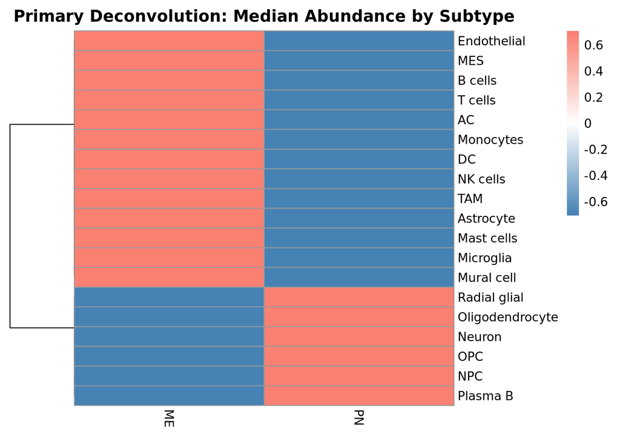

```r
#| fig-width: 8
#| fig-height: 6

# pivot to long format for ggplot
deconv_primary_long <- deconv_primary_df %>%
                       pivot_longer(
                         cols      = -c(sample_id, subtype),
                         names_to  = "cell_type",
                         values_to = "abundance_score"
                       )

# calculate median abundance score per cell type per subtype
deconv_primary_median_abundance_scores <- deconv_primary_long %>%
                                          group_by(cell_type, subtype) %>%
                                          summarise(median_score = median(abundance_score), .groups = "drop") %>%
                                          pivot_wider(names_from = subtype, values_from = median_score) %>%
                                          column_to_rownames("cell_type")

# plot heatmap
deconv_primary_median_abundance_scores_heatmap <- pheatmap(
  deconv_primary_median_abundance_scores,
  scale        = "row",
  cluster_cols = FALSE,
  main         = "Primary Deconvolution: Median Abundance by Subtype",
  color        = colorRampPalette(c("steelblue", "white", "salmon"))(100),
  silent       = TRUE
)$gtable

wrap_elements(deconv_primary_median_abundance_scores_heatmap)
```

##### 3.5.2.2. Plot Confirmatory Deconvolution Cell Type Abundance Scores Heatmap

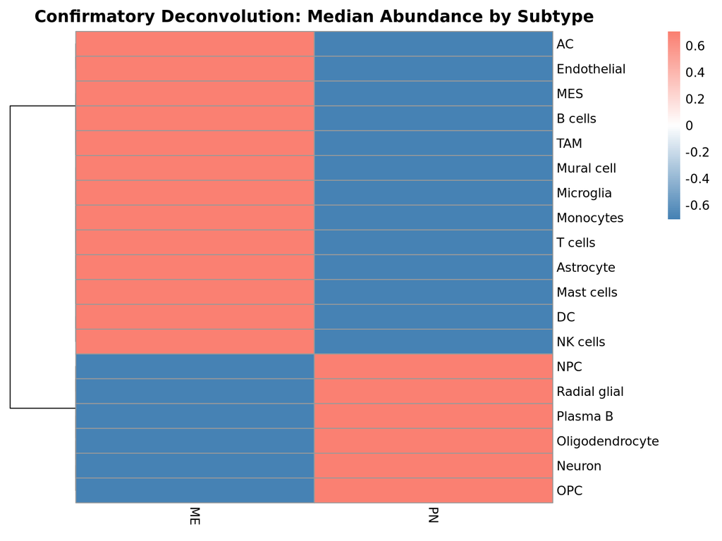

```r
# pivot to long format for ggplot
deconv_confirmatory_long <- deconv_confirmatory_df %>%
                            pivot_longer(
                              cols      = -c(sample_id, subtype),
                              names_to  = "cell_type",
                              values_to = "abundance_score"
                            )

# calculate median abundance score per cell type per subtype
deconv_confirmatory_median_abundance_scores <- deconv_confirmatory_long %>%
                                               group_by(cell_type, subtype) %>%
                                               summarise(median_score = median(abundance_score), .groups = "drop") %>%
                                               pivot_wider(names_from = subtype, values_from = median_score) %>%
                                               column_to_rownames("cell_type")

# plot heatmap
deconv_confirmatory_median_abundance_scores_heatmap <- pheatmap(
  deconv_confirmatory_median_abundance_scores,
  scale        = "row",
  cluster_cols = FALSE,
  main         = "Confirmatory Deconvolution: Median Abundance by Subtype",
  color        = colorRampPalette(c("steelblue", "white", "salmon"))(100),
  silent       = TRUE
)$gtable

wrap_elements(deconv_confirmatory_median_abundance_scores_heatmap)
```

##### 3.5.3.3. Combine Primary And Confirmatory Deconvolution Heatmaps

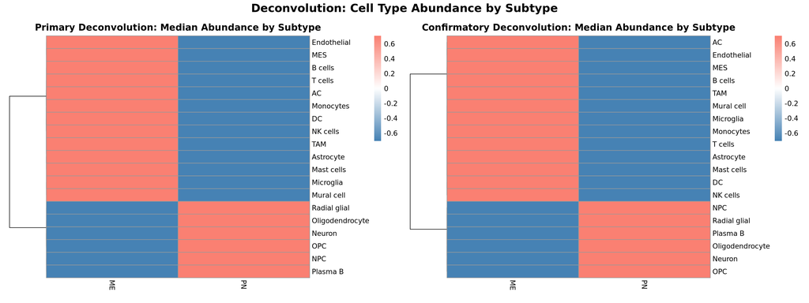

```r
deconv_combined_median_abundance_scores_heatmap <- (
  wrap_elements(deconv_primary_median_abundance_scores_heatmap) |
  wrap_elements(deconv_confirmatory_median_abundance_scores_heatmap)) +
  plot_annotation(
    title = "Deconvolution: Cell Type Abundance by Subtype",
    theme = theme(plot.title = element_text(hjust = 0.5, size = 16, face = "bold"))
  )

deconv_combined_median_abundance_scores_heatmap
```

The deconvolution results reveal **clear differences in cellular composition** between Proneural and Mesenchymal GBM tumors, consistent across both primary and confirmatory analyses:

- **Mesenchymal** tumors are **enriched for MES-like neoplastic cells** alongside a broad **immune and stromal infiltrate**: TAMs (Tumor-associated Macrophages), Microglia, Monocytes, Dendritic cells, T cells, B cells, NK (Natural Killer) cells, Mast cells, Endothelial cells and Mural cells are all relatively more abundant in ME samples.
  - **NOTE:** Mural cells are specialized cells that **wrap around blood vessels**. They specifically denote **pericytes** (found in **capillaries**) and **Vascular Smooth Muscle Cells** (vSMCs; found in **larger blood vessels**). **Arteries and arterioles** have **concentric vSMC layers** that form the **tunica media**. As they transition into **capillaries**, **vSMCs transition into pericytes**. As capillaries unite to form **venules and veins**, **pericytes transition into a thin layer of vSMCs** in the tunica media.
- **Proneural** tumors are **enriched for NPC-like (Neural Progenitor Cell-like) and OPC-like (Oligodendrocyte Progenitor Cell-like) neoplastic cells** alongside **neural cell types**: Neurons, Oligodendrocytes, and Radial glial cells are relatively more abundant in PN samples.

These findings are **consistent** across both the **primary** (Neftel neoplastic reference) and **confirmatory** (Moreno neoplastic reference) analyses, validating the robustness of the cell type abundance estimates.

## 4. Save Outputs

### 4.1. Save Deconvolution Results

```r
# save deconvolution result dataframes
saveRDS(deconv_primary_df,      "../04_results/07_deconvolution/01_primary_deconvolution_results.rds")
saveRDS(deconv_confirmatory_df, "../04_results/07_deconvolution/02_confirmatory_deconvolution_results.rds")

cat("Deconvolution results saved\n")
```

```
Deconvolution results saved
```

### 4.2. Save Combined Primary And Confirmatory Deconvolution Heatmap

```r
png(
  "../03_figures/07_deconvolution/deconv_combined_median_cell_type_abundance_scores_heatmap.png",
  width = 16,
  height = 6,
  units = "in",
  res = 300
)
grid::grid.draw(deconv_combined_median_abundance_scores_heatmap)
dev.off()
```

```r
cat("Deconvolution plots saved\n")
```

```
Deconvolution plots saved
```

## 5. Perform Sanity Checks

```r
primary_results_exists         <- file.exists("../04_results/07_deconvolution/01_primary_deconvolution_results.rds")
confirmatory_results_exists    <- file.exists("../04_results/07_deconvolution/02_confirmatory_deconvolution_results.rds")
combined_heatmap_exists        <- file.exists("../03_figures/07_deconvolution/deconv_combined_median_cell_type_abundance_scores_heatmap.png")

cat("Primary deconvolution results saved:                                    ", ifelse(primary_results_exists,      "✓", "✗"), "\n")
```

```
Primary deconvolution results saved:                                     ✓
```

```r
cat("Confirmatory deconvolution results saved:                               ", ifelse(confirmatory_results_exists, "✓", "✗"), "\n")
```

```
Confirmatory deconvolution results saved:                                ✓
```

```r
cat("Combined deconvolution median cell type abundance score heatmap saved:  ", ifelse(combined_heatmap_exists,     "✓", "✗"), "\n")
```

```
Combined deconvolution median cell type abundance score heatmap saved:   ✓
```

```r
if (all(primary_results_exists, confirmatory_results_exists,
        combined_heatmap_exists)) {
  cat("\nNotebook 07 complete — all outputs verified\n")
} else {
  cat("\nWARNING: One or more outputs missing\n")
}
```

```
Notebook 07 complete — all outputs verified
```